# Processos Estocásticos - Projeto 1

Integrantes do grupo:

Andrey Inácio Paulino - Nº USP 10818741

Gabriel Victor de Jesus Lima - Nº USP 10844226

Vikson Gianotti Andrade Dos Santos - Nº USP 10733900

imports

```python
import numpy as np
from numpy.linalg import matrix_power
from matplotlib import pyplot as plt
import networkx as nx
import matplotlib.pyplot as plt
from scipy.stats import pearsonr
import random
```

### Exercício 1

[figure not shown]

(a) Qual é a probabilidade da mosca escapar pela janela sem ser pega pela aranha? Assuma que a mosca se move pelo grafo escolhendo uma aresta com a mesma probabilidade e que ela nunca fica na mesma posição.

Para analisarmos o primeiro passo nesse problema, devido aos estados recorrentes, precisamos criar um sistema para definir a probabilidade desejada segundo:

$x = P_{10} + P_{11}x + P_{12}y + P_{13}z$ onde x é a probabilidade de absorção em 0 saindo do estado 1

$y = P_{20} + P_{21}x + P_{22}y + P_{23}z$ onde y é a probabilidade de absorção em 0 saindo do estado 2

$z = P_{30} + P_{31}x + P_{32}y + P_{33}z$ onde z é a probabilidade de absorção em 0 saindo do estado 3

Declarando o sistema em matriz:

$A=\begin{bmatrix} -1&1/2&0\\1/2&-1&1/2\\0&1/3&-1 \end{bmatrix}$

```python
A = [[-1, 1/2, 0],
    [1/2, -1, 1/2],
    [0, 1/3, -1]]

b = [-1/2, 0, -1/3] # resultados

estat1 = np.linalg.solve(A,b) # definicao das probabilidades de absorcao
print(estat1)
```

```
[0.85714286 0.71428571 0.57142857]
```

Para definir a absorção em 4(janela), precisamos encontrar os complementares das probabilidades encontradas.

```python
ajuste = [1,1,1]
absorcao_final = ajuste - estat1
resp1 = absorcao_final[0]

print(absorcao_final)
print("A probabilidade da mosca escapar pela janela sem ser pega pela aranha é",round(resp1,2))
```

```
[0.14285714 0.28571429 0.42857143]
A probabilidade da mosca escapar pela janela sem ser pega pela aranha é 0.14
```

(b) Calcule o número médio de visitas à maçã e à cadeira antes da mosca ser pega pela aranha ou sair pela janela. Assuma que a mosca iniciou na posição mostrada na figura.

Usando os resultados que temos sobre tempo médio ate a absorção, podemos criar o seguinte sistema:

$v_1= 1 + v_2/2$ Tempo médio para absorção partindo da posição 1 (Aranha)

$v_2 = 1 + (v_1 + v_3)/2$ Tempo médio para absorção partindo da posição 2 (Maçã)

$v_3 = 1 + v_2/3$ Tempo médio para absorção partindo da posição 3 (Cadeira)

Declaração do sistema em uma matriz:

$B=\begin{bmatrix} -1 & 2 & -1\\ 2 & -1 & 0\\ 0 & -1 & -3 \end{bmatrix}$

Resolvendo o sistema:

```python
B = [[-1, 2, -1],
    [2, -1, 0],
    [0, -1, -3]]

r =[2,2,3] # resultados

estat2 = np.linalg.solve(B,r)
print(estat2)
```

```
[ 1.54545455  1.09090909 -1.36363636]
```

```python
print(estat2[0]) # Tempo medio gasto saindo da maca
print(estat2[1]) # Tempo medio gasto saindo da cadeira
```

```
1.5454545454545454
1.0909090909090908
```

(c) Assuma agora que a aranha não está na posição indicada, ou seja, a posição está vazia. Qual é o tempo médio que a mosca leva para sair pela janela?

Para analisarmos o primeiro passo nesse problema, devido aos estados recorrentes, precisamos criar um sistema para definir a probabilidade desejada segundo:

$v_1 = 1 + v_2$ Tempo médio para absorção partindo da posição 1(Arannha)

$v_2 = 1 + (v_1 + v_3)/2$ Tempo médio para absorção partindo da posição 2(Maçã)

$v_3 = 1 + v_2/2$ Tempo médio para absorção partindo da posição 3 (Cadeira)

Declaração do sistema em uma matriz:

$C = \begin{bmatrix} 1 & -1 & 0\\ -1/2 & 1 & -1/2\\ 0 & -1/2 & 1 \end{bmatrix}$

Resolvendo o sistema:

```python
C = [[1, -1, 0],
     [-1/2, 1, -1/2],
     [0, -1/2, 1]]

r2 = [1,1,1] # resultados

estat3 = np.linalg.solve(C,r2)

print(estat3)
print(estat3[0])               # Tempo medio para sair pela janela
```

```
[9. 8. 5.]
9.0
```

(d) Simule esse problema e compare os resultados teóricos obtidos em (a), (b) e (c). Verifique como os resultados mudam em função do número de experimentos.

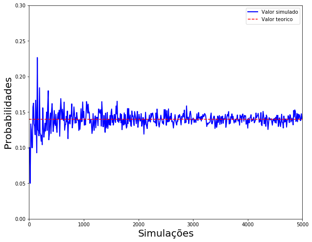

```python
p = 0.14 # probabilidade do exercicio (a)
vp = [] # lista que armazena a fração de ocorrências em função do número de simulações nsim
vsim = [] # armazena o numero de simulacoes
Nmax = 5000 # numero maximo de simulacoes
for nsim in np.arange(0,Nmax,10):
    num = 0
    for i in range(1,nsim):
        if(np.random.uniform() < p):
            num = num + 1
    vp.append(num/nsim)
    vsim.append(nsim)

plt.figure(figsize=(10,8))
plt.plot(vsim, vp, linestyle='-', color="blue", linewidth=2,label = 'Valor simulado')
plt.axhline(y=p, color='r', linestyle='--', label = 'Valor teorico')
plt.ylabel("Probabilidades", fontsize=20)
plt.xlabel("Simulações", fontsize=20)
plt.xlim([0.0, Nmax])
plt.ylim([0, 0.3])
plt.legend()
plt.show(True)
```

### Exercício 2

a) A probabilidade do jogador A vencer em um jogo é p = 0,49. Ele começa o jogo com R$ 6,00. Seu oponente, o jogador B, começa com R$ 10,00. Qual a probabilidade de A vencer? Assuma que em cada jogo é apostado R$ 2,00 pelo jogador contra o seu oponente.

```python
resultado = ((0.51/0.49)**(6)-(0.51/0.49)**(16))/(1-(0.51/0.49)**16)
Prob = 1 - resultado

print(Prob)
```

```
0.3025617931565586
```

b) Simule o problema acima e compare o resultado com o resultado teórico.

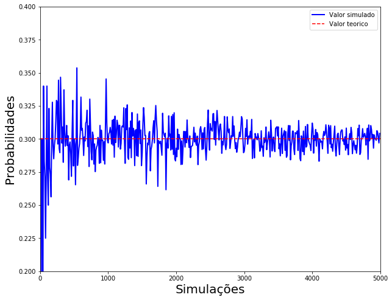

```python
p = 0.3 # probabilidade do exercicio (a)
vp = [] # lista que armazena a fração de ocorrências em função do número de simulações nsim
vsim = [] # armazena o número de simulações
Nmax = 5000 # numero maximo de simulacoes
for nsim in np.arange(0,Nmax,10):
    num = 0
    for i in range(1,nsim):
        if(np.random.uniform() < p):
            num = num + 1
    vp.append(num/nsim)
    vsim.append(nsim)

plt.figure(figsize=(10,8))
plt.plot(vsim, vp, linestyle='-', color="blue", linewidth=2,label = 'Valor simulado')
plt.axhline(y=p, color='r', linestyle='--', label = 'Valor teorico')
plt.ylabel("Probabilidades", fontsize=20)
plt.xlabel("Simulações", fontsize=20)
plt.xlim([0.0, Nmax])
plt.ylim([0.2,0.4])
plt.legend()
plt.show(True)
```

c) Simule agora o problema em que três apostadores jogam entre si, apostando um com o outro. Sejam as probabilidades de ganho de cada um, p1, p2 e p3. Analise as chances de ganho do jogador 1 considerando diferentes valores das probabilidades e fortuna inicial.

```python
resultado1 = ((0.6/0.4)**(6)-(0.6/0.4)**(16))/(1-(0.6/0.4)**16) # Simulnado probabilidades e fortuna iniciais diferentes
Prob1 = 1 - resultado1

resultado2 = ((0.55/0.45)**(5)-(0.55/0.45)**(15))/(1-(0.55/0.45)**15) # Simulnado probabilidades e fortuna iniciais diferentes
Prob2 = 1 - resultado2

print(Prob1)
print(Prob2)
```

```
0.015843211395870083
0.08955603314647387
```

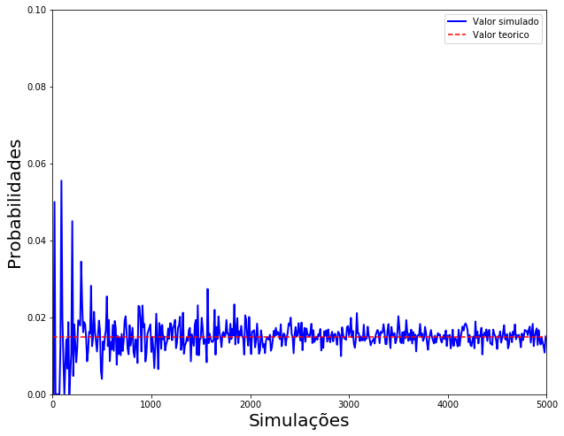

```python
p = 0.015 # probabilidade do exercicio simualado(resultado1)
vp = [] # lista que armazena a fração de ocorrências em função do número de simulações nsim
vsim = [] # armazena o número de simulações
Nmax = 5000 # numero maximo de simulacoes
for nsim in np.arange(0,Nmax,10):
    num = 0
    for i in range(1,nsim):
        if(np.random.uniform() < p):
            num = num + 1
    vp.append(num/nsim)
    vsim.append(nsim)

plt.figure(figsize=(10,8))
plt.plot(vsim, vp, linestyle='-', color="blue", linewidth=2,label = 'Valor simulado')
plt.axhline(y=p, color='r', linestyle='--', label = 'Valor teorico')
plt.ylabel("Probabilidades", fontsize=20)
plt.xlabel("Simulações", fontsize=20)
plt.xlim([0.0, Nmax])
plt.ylim([0,0.1])
plt.legend()
plt.show(True)
```

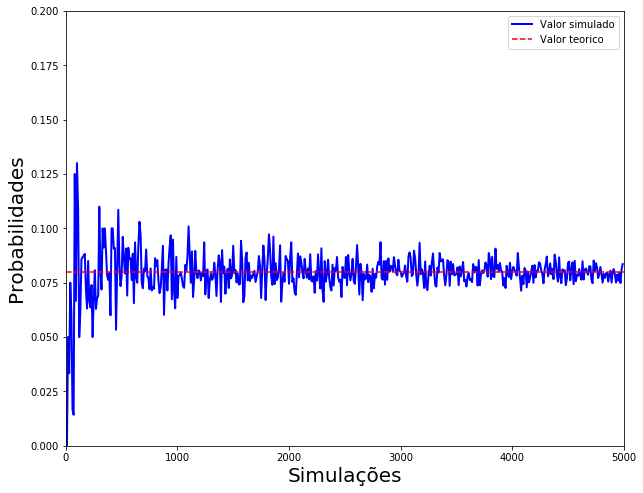

```python
p = 0.08 # probabilidade do exercicio simulado(resultado2)
vp = [] # lista que armazena a fração de ocorrências em função do número de simulações nsim
vsim = [] # armazena o número de simulações
Nmax = 5000 # numero maximo de simulacoes
for nsim in np.arange(0,Nmax,10):
    num = 0
    for i in range(1,nsim):
        if(np.random.uniform() < p):
            num = num + 1
    vp.append(num/nsim)
    vsim.append(nsim)

plt.figure(figsize=(10,8))
plt.plot(vsim, vp, linestyle='-', color="blue", linewidth=2,label = 'Valor simulado')
plt.axhline(y=p, color='r', linestyle='--', label = 'Valor teorico')
plt.ylabel("Probabilidades", fontsize=20)
plt.xlabel("Simulações", fontsize=20)
plt.xlim([0.0, Nmax])
plt.ylim([0,0.2])
plt.legend()
plt.show(True)
```

### Exercicio 3

a) Escreva a matriz de probabilidades de transição e determine o número médio de lançamentos necessários.

Declaração:

$ D = \begin{bmatrix} 1/2 & 1/2 & 0 \\ 1/2 & 0 & 1/2\\ 0 & 0 & 1 \end{bmatrix} $

Usando os resultados que temos sobre tempo médio ate a absorção, podemos criar o seguinte sistema:

$v_2 = 1 + v_1/2$ Tempo medio para absorção partindo da posição 1 (1 Cara)

Declaração do sistema em uma matriz:

$ E = \begin{bmatrix} 1 & -1 \\ -1 & 2 \end{bmatrix} $

Resolvendo o sistema:

```python
E = [[1, -1],
     [-1, 2]]

r3 = [2,2] # resultados

estat4 = np.linalg.solve(E,r3)
print(estat4)
print(estat4[0])
```

```
[6. 4.]
6.0
```

b) Simule esse problema e compare o resultado com o valor teórico. Faça um gráfico da probabilidade obtida em função do número de experimentos. Considere ao menos três valores para p

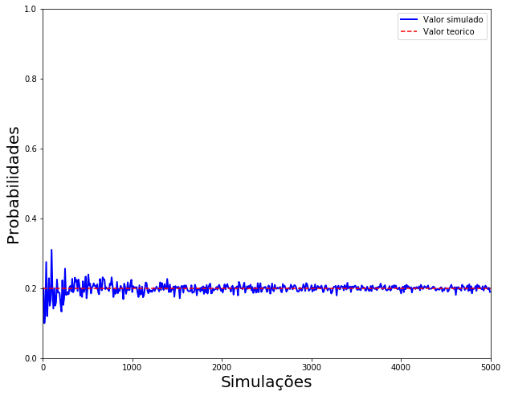

```python
p = 0.2
vp = [] # lista que armazena a fração de ocorrências em função do número de simulações nsim
vsim = [] # armazena o número de simulações
Nmax = 5000 # numero maximo de simulacoes
for nsim in np.arange(0,Nmax,10):
    num = 0
    for i in range(1,nsim):
        if(np.random.uniform() < p):
            num = num + 1
    vp.append(num/nsim)
    vsim.append(nsim)

plt.figure(figsize=(10,8))
plt.plot(vsim, vp, linestyle='-', color="blue", linewidth=2,label = 'Valor simulado')
plt.axhline(y=p, color='r', linestyle='--', label = 'Valor teorico')
plt.ylabel("Probabilidades", fontsize=20)
plt.xlabel("Simulações", fontsize=20)
plt.xlim([0.0, Nmax])
plt.ylim([0,1])
plt.legend()
plt.show(True)
```

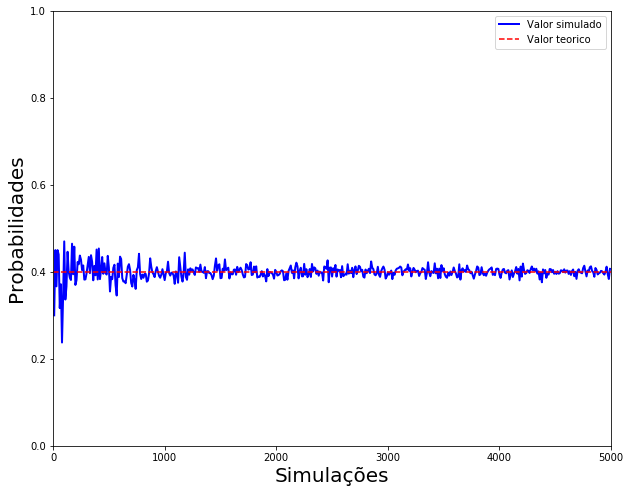

```python
p = 0.4
vp = [] # lista que armazena a fração de ocorrências em função do número de simulações nsim
vsim = [] # armazena o número de simulações
Nmax = 5000 # numero maximo de simulacoes
for nsim in np.arange(0,Nmax,10):
    num = 0
    for i in range(1,nsim):
        if(np.random.uniform() < p):
            num = num + 1
    vp.append(num/nsim)
    vsim.append(nsim)

plt.figure(figsize=(10,8))
plt.plot(vsim, vp, linestyle='-', color="blue", linewidth=2,label = 'Valor simulado')
plt.axhline(y=p, color='r', linestyle='--', label = 'Valor teorico')
plt.ylabel("Probabilidades", fontsize=20)
plt.xlabel("Simulações", fontsize=20)
plt.xlim([0.0, Nmax])
plt.ylim([0,1])
plt.legend()
plt.show(True)
```

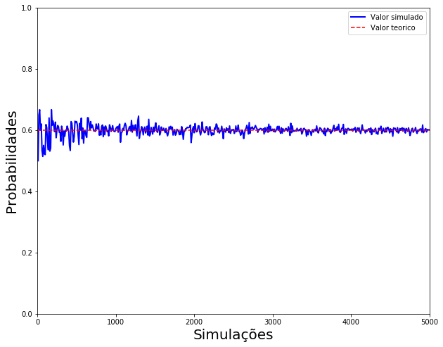

```python
p = 0.6
vp = [] # lista que armazena a fração de ocorrências em função do número de simulações nsim
vsim = [] # armazena o número de simulações
Nmax = 5000 # numero maximo de simulacoes
for nsim in np.arange(0,Nmax,10):
    num = 0
    for i in range(1,nsim):
        if(np.random.uniform() < p):
            num = num + 1
    vp.append(num/nsim)
    vsim.append(nsim)

plt.figure(figsize=(10,8))
plt.plot(vsim, vp, linestyle='-', color="blue", linewidth=2,label = 'Valor simulado')
plt.axhline(y=p, color='r', linestyle='--', label = 'Valor teorico')
plt.ylabel("Probabilidades", fontsize=20)
plt.xlabel("Simulações", fontsize=20)
plt.xlim([0.0, Nmax])
plt.ylim([0,1])
plt.legend()
plt.show(True)
```

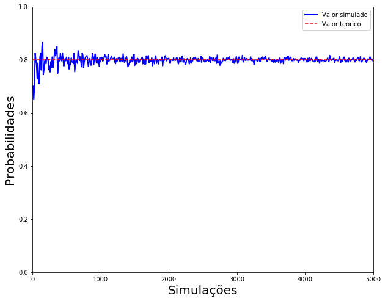

```python
p = 0.8
vp = [] # lista que armazena a fração de ocorrências em função do número de simulações nsim
vsim = [] # armazena o número de simulações
Nmax = 5000 # numero maximo de simulacoes
for nsim in np.arange(0,Nmax,10):
    num = 0
    for i in range(1,nsim):
        if(np.random.uniform() < p):
            num = num + 1
    vp.append(num/nsim)
    vsim.append(nsim)

plt.figure(figsize=(10,8))
plt.plot(vsim, vp, linestyle='-', color="blue", linewidth=2,label = 'Valor simulado')
plt.axhline(y=p, color='r', linestyle='--', label = 'Valor teorico')
plt.ylabel("Probabilidades", fontsize=20)
plt.xlabel("Simulações", fontsize=20)
plt.xlim([0.0, Nmax])
plt.ylim([0,1])
plt.legend()
plt.show(True)
```

## Exercício 4

a) Determine a distribuição de probabilidade estacionária.

```python
y = np.array([[0,3/6,0,1/6,2/6],[1,0,0,0,0],[0,0,0,0,1],[1/5,0,0,0,4/5],[2/12,0,6/12,4/12,0]])
```

```python
eigvals, eigvecs = np.linalg.eig(y.T)
eigvec1 = eigvecs[:,np.isclose(eigvals, 1)]
eigvec1 = eigvec1[:,0]
stationary = eigvec1 / eigvec1.sum()
stationary = stationary.real
for i in range(0,5):
    print(i+1, ':', stationary[i])
```

```
1 : 0.1875000000000001
2 : 0.09374999999999999
3 : 0.18750000000000006
4 : 0.15625
5 : 0.37499999999999994
```

b)Implemente uma rotina que simule uma caminha aleatória no grafo. Verifique que após um grande número de passos, o número médio de visitas a cada estado se aproxima da distribuição estacionária.

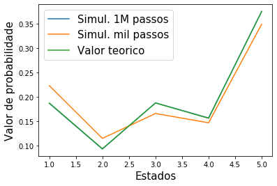

```python
#valor simulado
vaposta=[1,2,3,4,5]
vp = [0.186815, 0.093186, 0.187762, 0.156839, 0.375398]
plt.plot(vaposta,vp, label = 'Simul. 1M passos')
plt.xlabel('Estados', fontsize = 15)
plt.ylabel('Valor de probabilidade', fontsize = 15)

vp1 = [0.223, 0.115, 0.166, 0.147, 0.349]
plt.plot(vaposta,vp1, label = 'Simul. mil passos')

#valor teorico
#prob.estacionaria
vpt = [0.18749999999999983, 0.09374999999999975, 0.18750000000000008,0.15625000000000003, 0.3750000000000003]
vapostat = [1,2,3,4,5] #aposta
plt.plot(vapostat,vpt,label='Valor teorico')
plt.legend(fontsize=15)
plt.show(True)
```

## Exercício 5

#### Considere a rede dos personagens do livro "Os Miseráveis", de Victor Hugo (disponível no Moodle).

#### Implemente e calcule o PageRank para cada vértice. Simule uma caminha aleatória e veriﬁque se o número de visitas a cada vértice é relacionado com o PageRank.

Lendo o conjunto de dados

```python
H = nx.read_gml("lesmis.gml")
```

Passando para matriz

```python
X = nx.to_numpy_matrix(H)
print(X)
```

```
[[0. 1. 1. ... 0. 0. 0.]
 [1. 0. 0. ... 0. 0. 0.]
 [1. 0. 0. ... 0. 0. 0.]
 ...
 [0. 0. 0. ... 0. 0. 0.]
 [0. 0. 0. ... 0. 0. 0.]
 [0. 0. 0. ... 0. 0. 0.]]
```

Transformando na matriz de transição

```python
n = X.shape[0] # armazena o numero de linhas
Z = np.zeros((n,n)) # matriz de zeros NxN
for i in range(0,n):
    for j in range(0,n):
        if(np.sum(X[i,:]) > 0):
            Z[i,j] = X[i,j]/np.sum(X[i,:]) # se tiver relacionamento atribui probabilidade
        else:
            Z[i,j] = 1/n # caso contrario atribui a mesma probabilidade para os relacionamentos
print(Z)
```

```
[[0.         0.1        0.1        ... 0.         0.         0.        ]
 [1.         0.         0.         ... 0.         0.         0.        ]
 [0.33333333 0.         0.         ... 0.         0.         0.        ]
 ...
 [0.         0.         0.         ... 0.         0.         0.        ]
 [0.         0.         0.         ... 0.         0.         0.        ]
 [0.         0.         0.         ... 0.         0.         0.        ]]
```

Gerando a matriz Google

```python
G = np.zeros((n,n))
alpha = 0.85
for i in range(0,n):
    for j in range(0,n):
        G[i,j] = alpha*Z[i,j] + (1-alpha)/n
print(G)
```

```
[[0.00194805 0.08694805 0.08694805 ... 0.00194805 0.00194805 0.00194805]
 [0.85194805 0.00194805 0.00194805 ... 0.00194805 0.00194805 0.00194805]
 [0.28528139 0.00194805 0.00194805 ... 0.00194805 0.00194805 0.00194805]
 ...
 [0.00194805 0.00194805 0.00194805 ... 0.00194805 0.00194805 0.00194805]
 [0.00194805 0.00194805 0.00194805 ... 0.00194805 0.00194805 0.00194805]
 [0.00194805 0.00194805 0.00194805 ... 0.00194805 0.00194805 0.00194805]]
```

Calculando a distribuição estacionária

```python
eigvals, eigvecs = np.linalg.eig(G.T)
eigvec1 = eigvecs[:,np.isclose(eigvals, 1)]
eigvec1 = eigvec1[:,0]
stationary = eigvec1 / eigvec1.sum()
stationary = stationary.real

for i in range(0,n):
    print(i+1, ':', stationary[i])
```

```
1 : 0.04277928102271222
2 : 0.005584290834982499
3 : 0.01027713462973789
4 : 0.010277134629737885
5 : 0.0055842908349825
6 : 0.0055842908349825
7 : 0.0055842908349825
8 : 0.0055842908349825
9 : 0.0055842908349825
10 : 0.0055842908349825
11 : 0.003729040931048255
12 : 0.07543012163278469
13 : 0.005260327543023243
14 : 0.003729040931048255
15 : 0.003729040931048255
```

[output cut: 62 more lines]

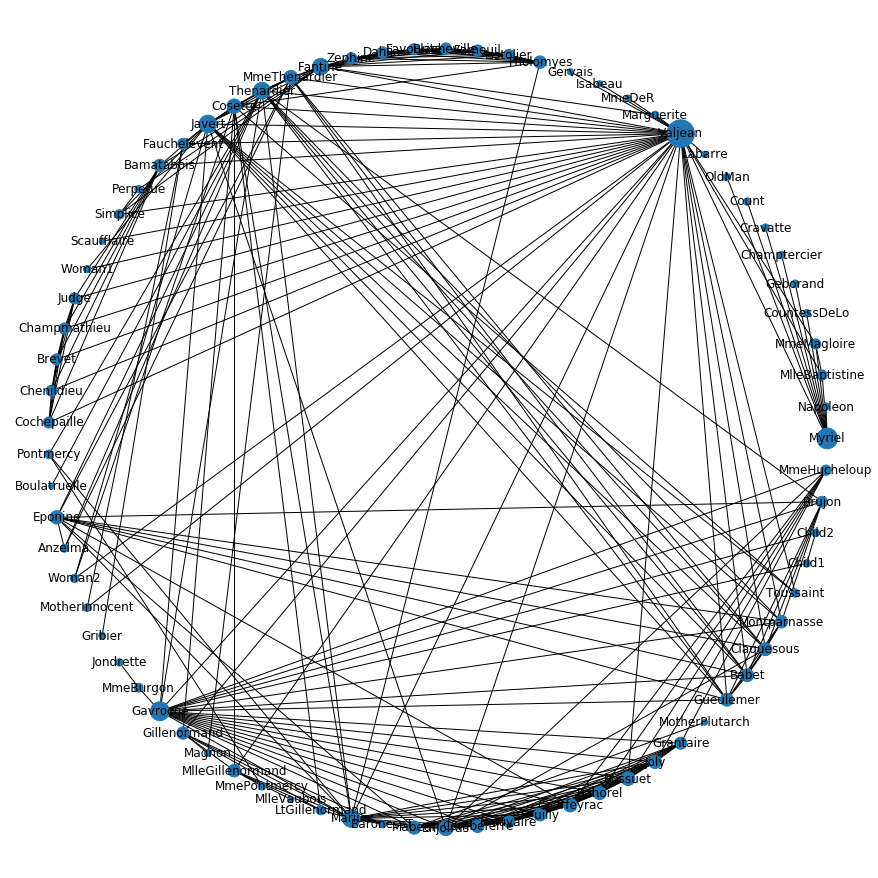

```python
options = {
    'node_color': 'blue',
    'node_size': 1000,
    'width': 1,
    'arrowstyle': '-|>',
    'arrowsize': 20,
}

npos=nx.circular_layout(H)
s = stationary*10000
fig = plt.figure(figsize=(12, 12))
nx.draw(H,pos = npos, with_labels=True, node_size = s, arrows=True)
plt.draw()
plt.show()
```

Simulando a caminhada aleatória

```python
passos = 10000
v_inicio, ini = 0 , 0
qtd = np.zeros(len(Z)) # qtde de visitas em cada vertice
caminhada , v_vizinho = [] , []
for i in range(2):
    qtd[ini] += 1
    caminhada +=[ini] # armazena os vertices visitados
    for j in range(0,passos):
        v_vizinho = []
        for k in range(0,len(Z[0])):
            if Z[ini,k]  > 0: # verifica relacao
                v_vizinho += [k] # armazena vertices vizinhos
        passo = np.random.choice(v_vizinho) # escolha aleatoria do proximo passo
        qtd[passo] += 1
        caminhada += [passo]
        ini = caminhada[-1]
        v_vizinho.clear()
    v_inicio += 1
    ini = v_inicio

c = []
for m in range(len(qtd)):
    l = [m/sum(qtd)]
    c.append(l)
```

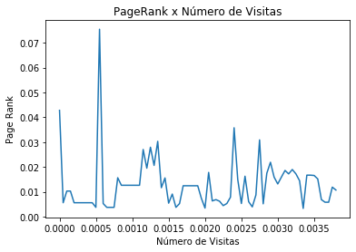

```python
a = np.reshape(c, (77, 1)) # caminhada aleatoria
b = np.reshape(stationary, (77, 1)) # pagerank

plt.title('PageRank x Número de Visitas')
plt.plot(a,b)
plt.xlabel("Número de Visitas")
plt.ylabel("Page Rank")
plt.show()
```